# activity_analysis

Ben Hicks

15/10/2019

# Topological Data Analysis

The most interseting story was comparing the transition of the two subjects from 2017 to 2018 (with the change in resource design), and how this appears to affect the relationship between performance in the subject (*grade*, coloured) and online behaviour in the subject.

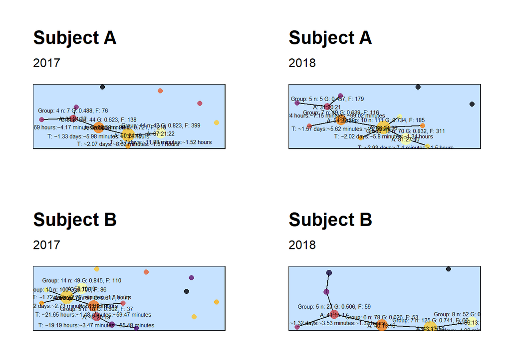

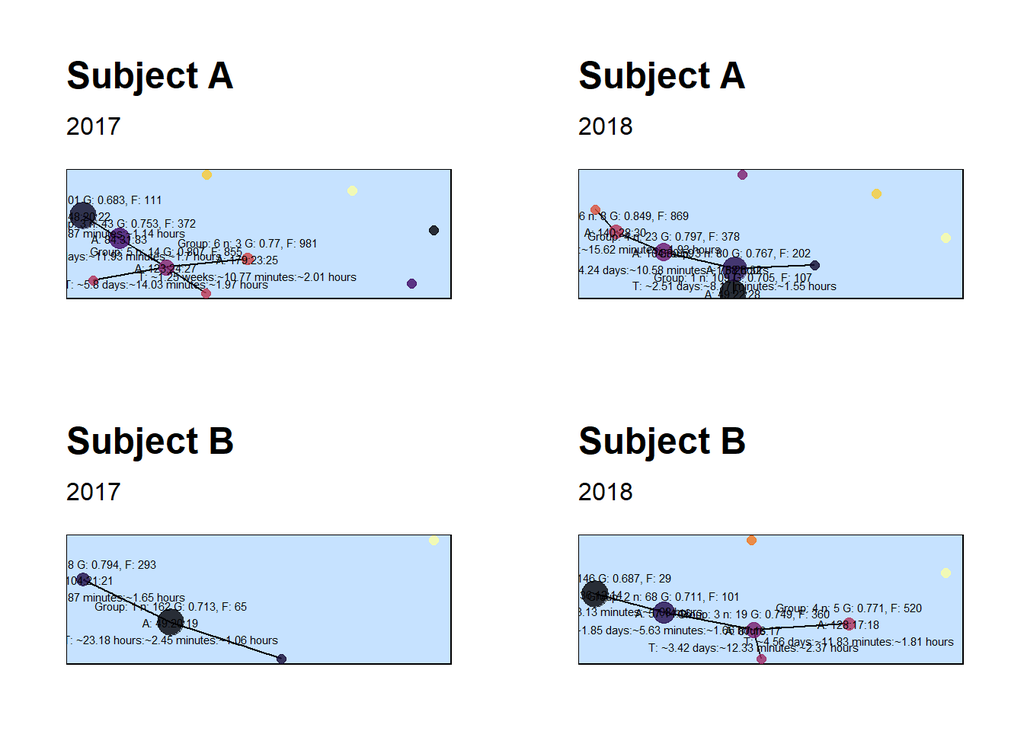

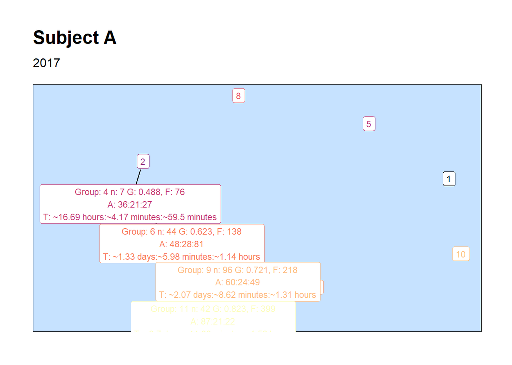

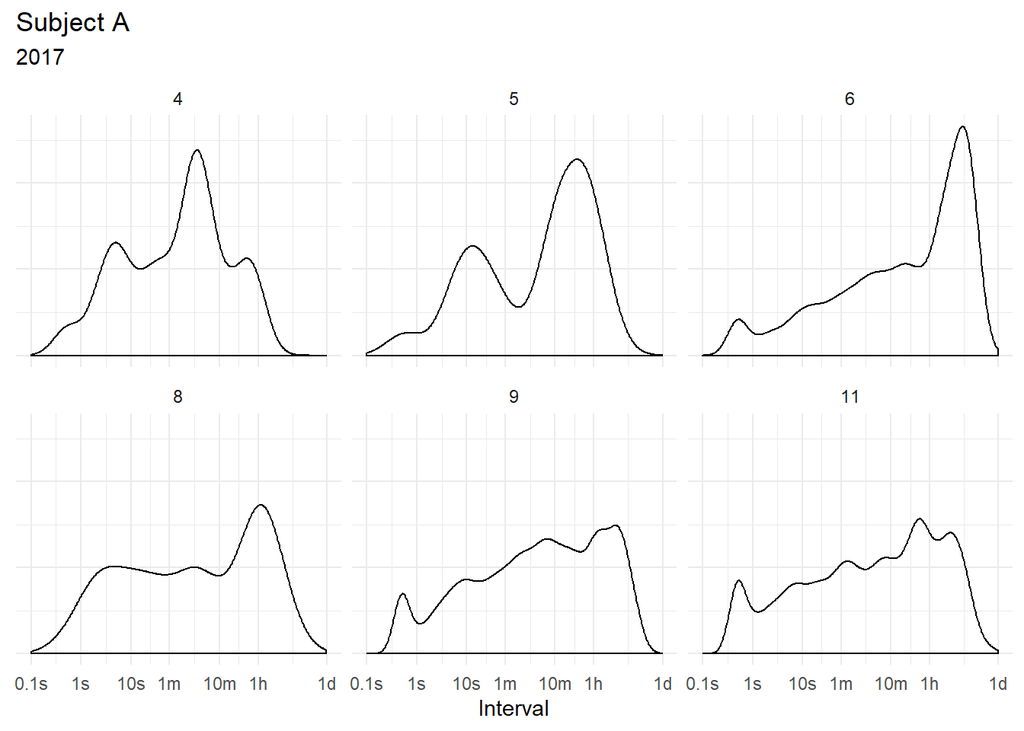

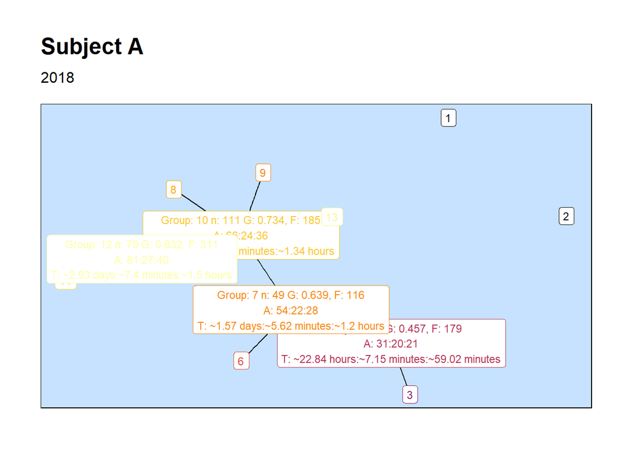

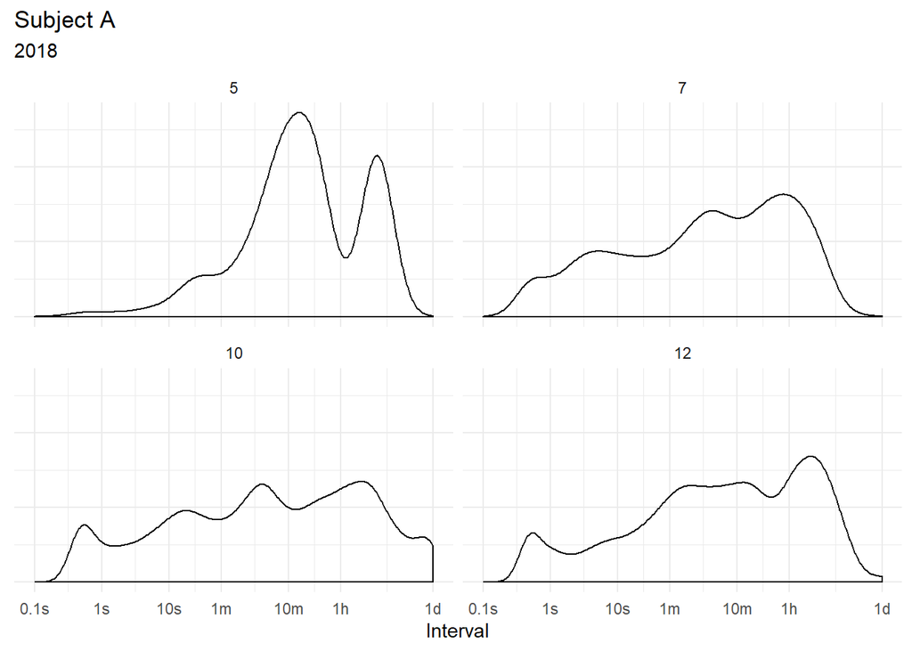

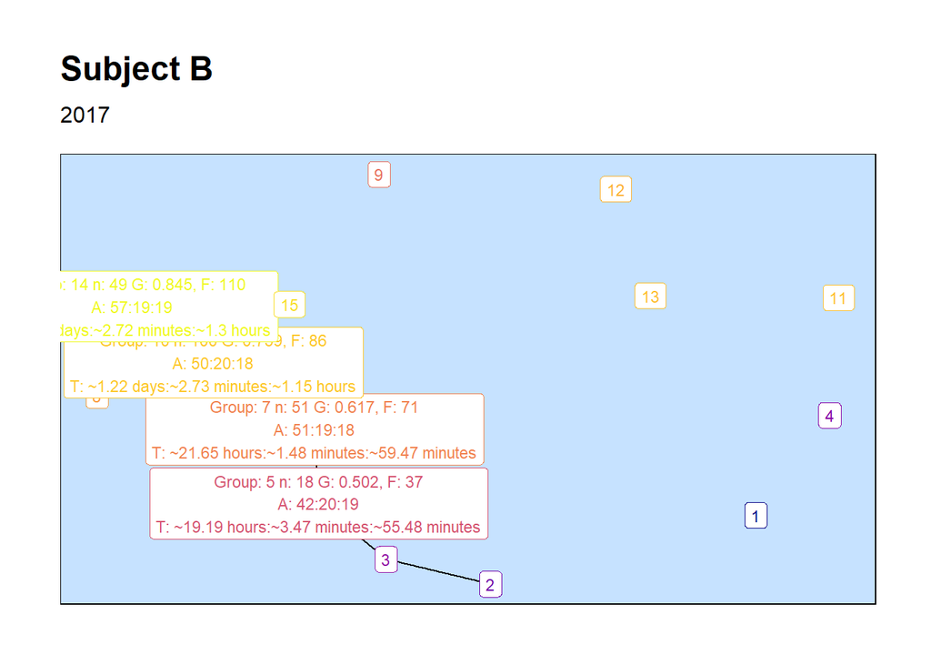

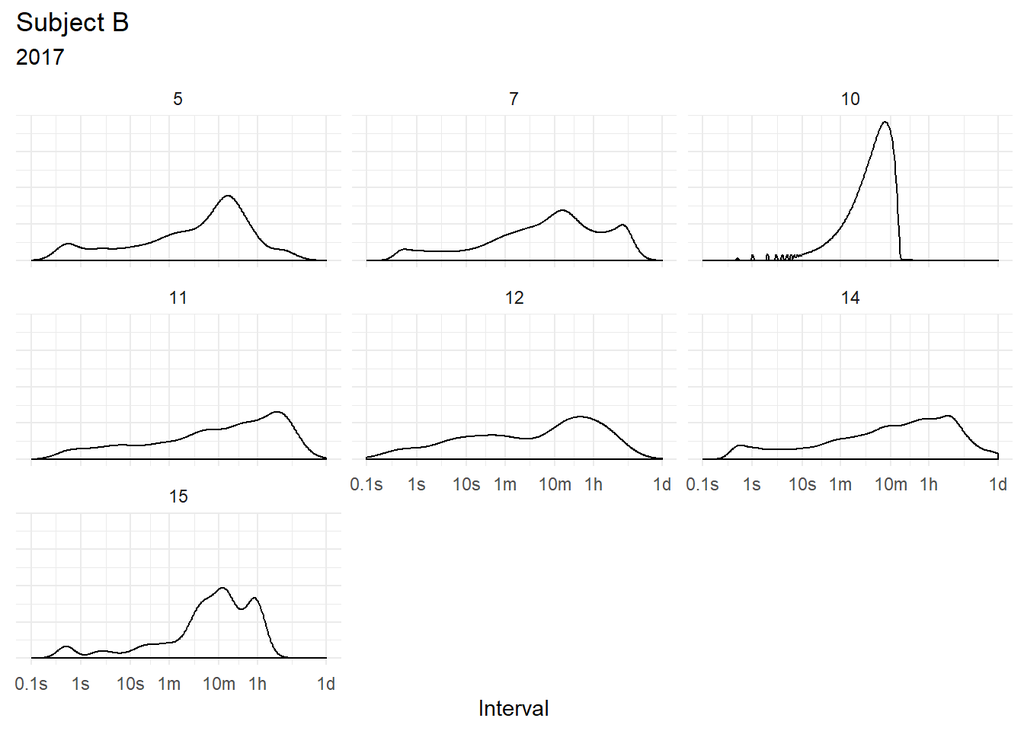

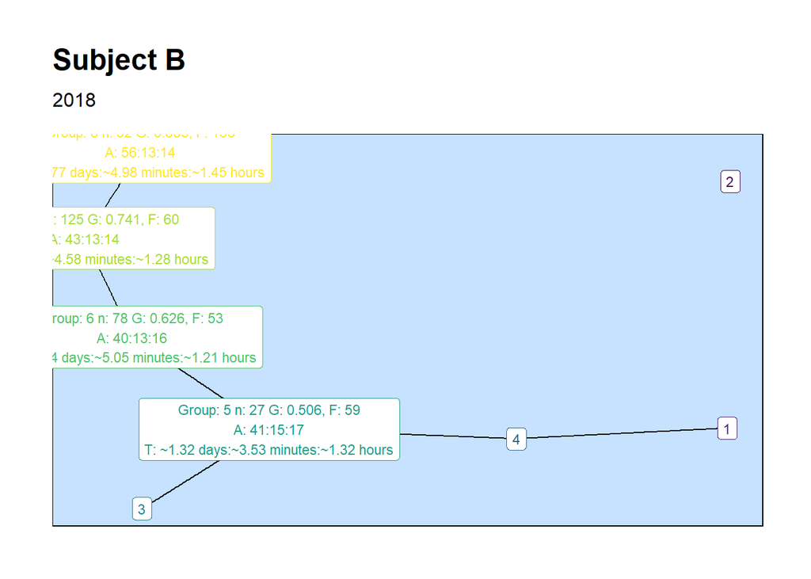

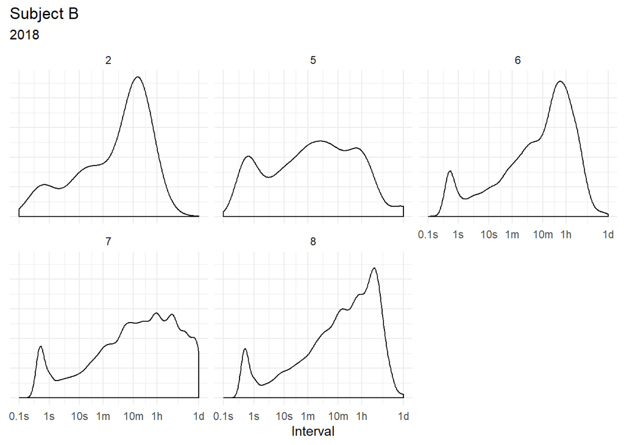

Of note is the ‘self regulation’ section between 1-10 seconds (wanting this low for higher self regulation), particularly in Sub B 2018.

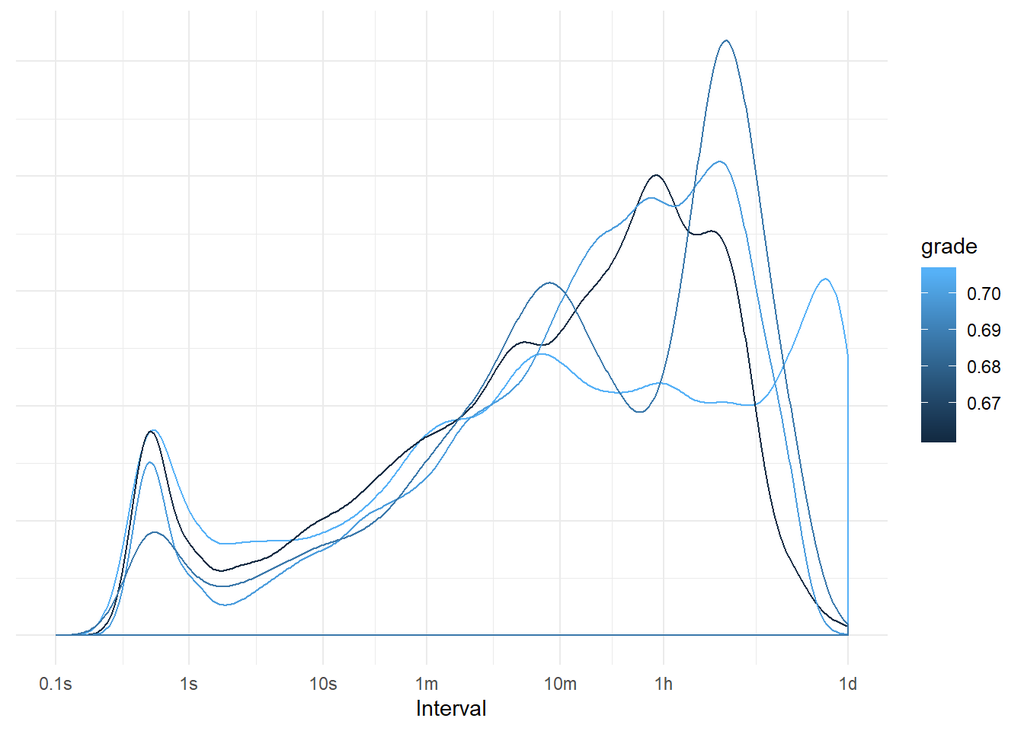

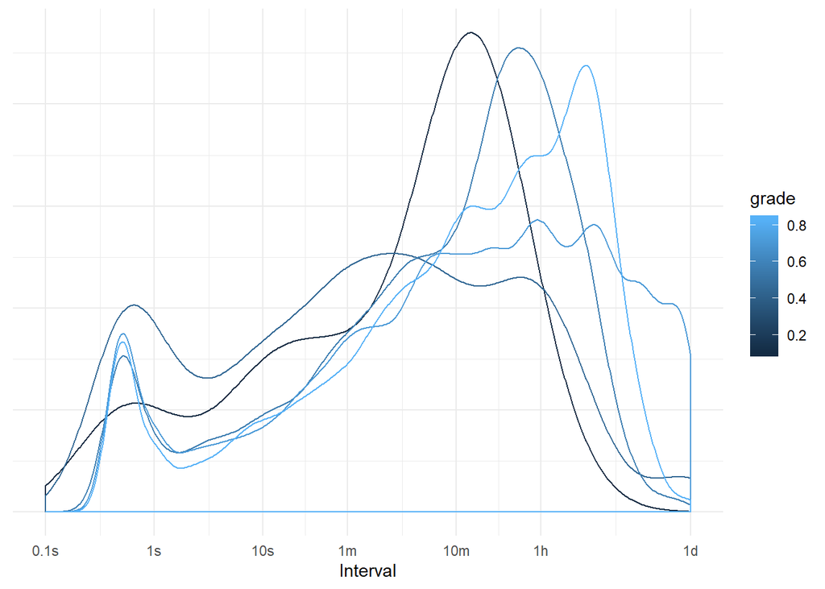

### Persistant Homology

It is challenging to compute persistant homology barcodes or birth-death diagrams for 7 or 8 dimensional space, even with bootstrapping small samples, so here I have used the first 3 principal components as a representation for this data. The 3 components exclude grade data, so this is performed again with an additional Grade dimension.

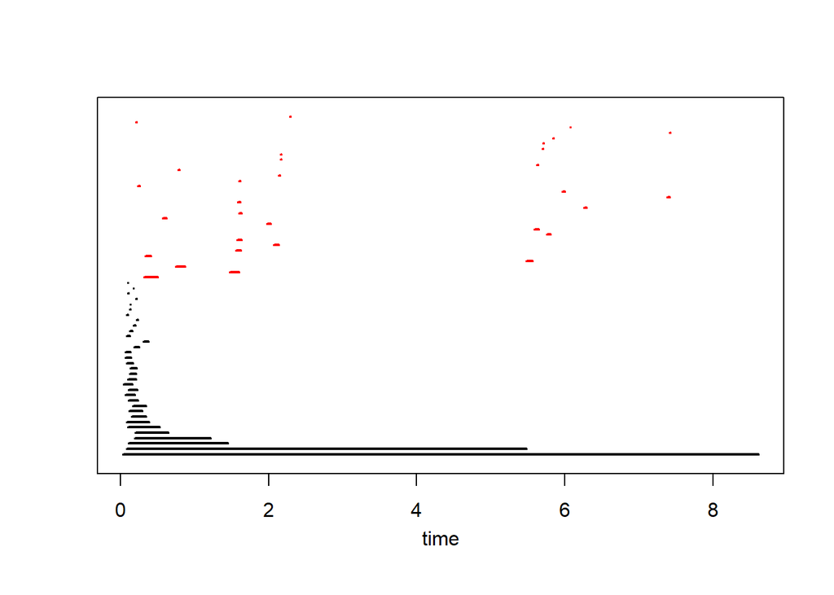

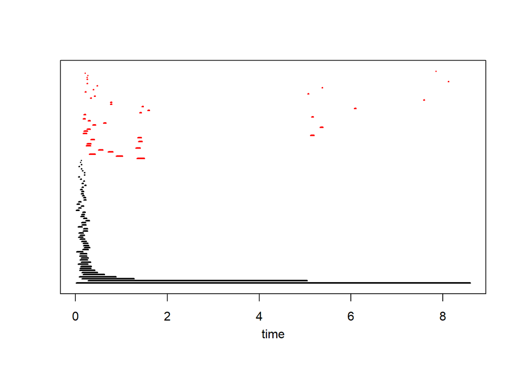

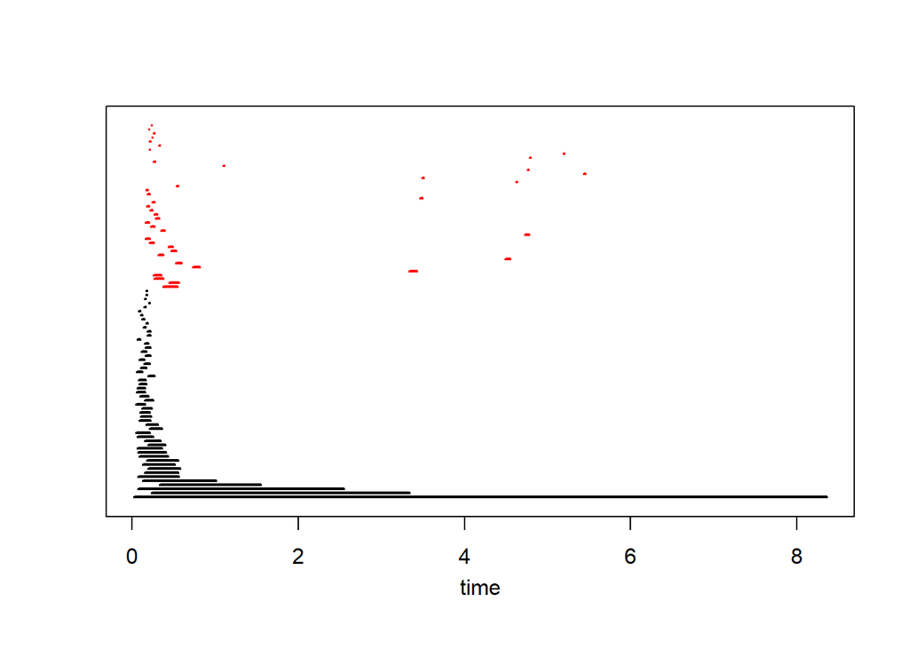

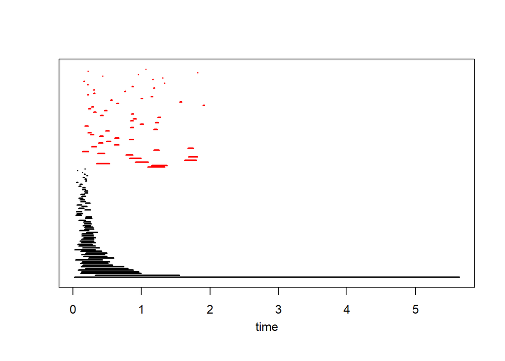

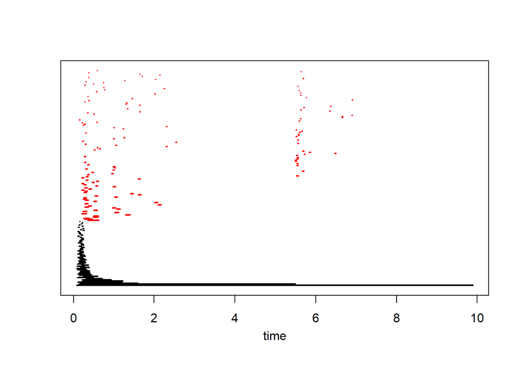

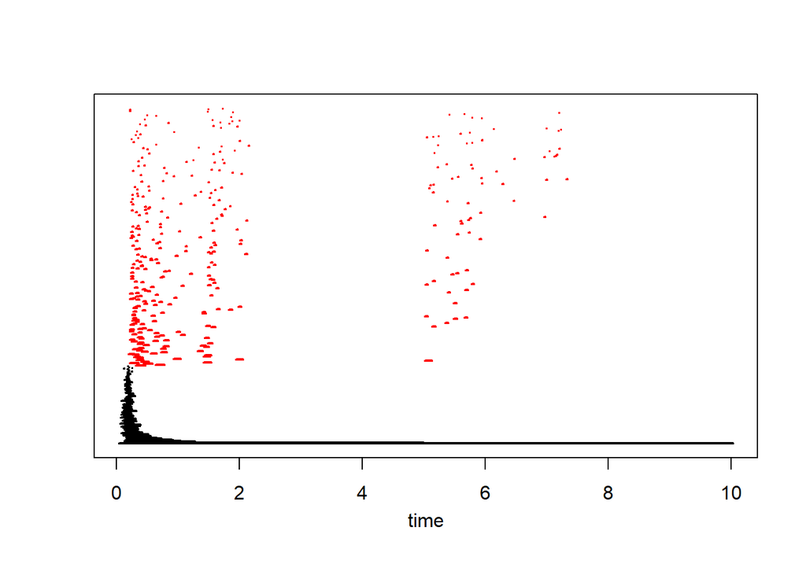

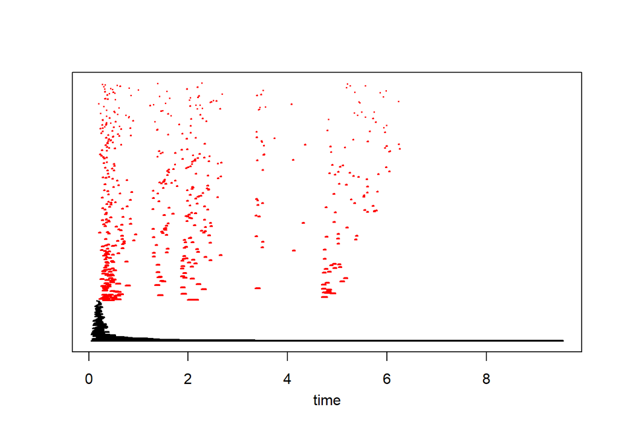

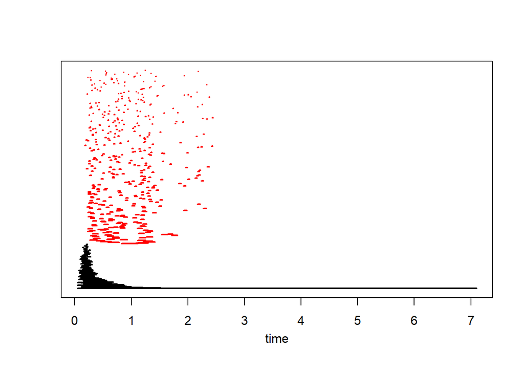